# 10-Tarea: bootstrap paramétrico

```r
knitr::opts_chunk$set(
    comment = "#>",
    collapse = TRUE
  )
comma <- function(x) format(x, digits = 2, big.mark = ",")
options(digits=3)

library(tidyverse)
library(gridExtra)
theme_set(theme_minimal())
```

1. Sean $X_1,...,X_n \sim N(\mu, 1)$. Sea $\theta = e^{\mu}$, crea una base de datos usando $\mu=5$ que consista de $n=100$ observaciones.

```r
set.seed(92417)
n<-100
x<-rnorm(n,5,1)
```

*Usa el método delta para estimar $\hat{se}$ y crea un intervalo del 95% de confianza. Usa boostrap paramétrico para crear un intervalo del 95%. Usa bootstrap no paramétrico para crear un intervalo del 95%. Compara tus respuestas.

```r
# Paso 1: calcular mu_hat y sigma_hat
repBN<-function(){
  x_star<-sample(x,n,replace=TRUE)
  exp(mean(x_star))
}

mu_hat<-mean(x)

repB<-function(){
  x_star<-rnorm(n,mu_hat,1)
  exp(mean(x_star))
}

repsBN<-rerun(1000,repBN())%>%flatten_dbl()
repsB<-rerun(1000,repB())%>%flatten_dbl()
sd(repsBN)
```

```
#> [1] 17
```

```r
sd(repsB)
```

```
#> [1] 15.2
```

```r
dat<-data.frame(metodo=c(rep("BN",1000),rep("BP",1000),rep("delta",1000)),sims=c(repsBN,repsB,rnorm(1000,exp(mu_hat),sd(repsBN))))

#intervalo delta
ICd<-c(exp(mu_hat)-1.96*sd(repsBN),exp(mu_hat)+1.96*sd(repsBN))
ICd
```

```
#> [1] 119 186
```

```r
#intervalo no parametrico
ICBN<-c(round(quantile(repsBN, prob = 0.025), 2),round(quantile(repsBN, prob = 0.975) , 2))
ICBN
```

```
#>  2.5% 97.5%
#>   124   188
```

```r
#intervalo paametrico
ICB<-c(round(quantile(repsB, prob = 0.025), 2),round(quantile(repsB, prob = 0.975) , 2))
ICB
```

```
#>  2.5% 97.5%
#>   126   185
```

*Realiza un histograma de replicaciones bootstrap para cada método, estas son estimaciones de la distribución de $\hat{\theta}$. El método delta también nos da una aproximación a esta distribución: $Normal(\hat{\theta},\hat{se}^2)$. Comparalos con la verdadera distribución de $\hat{\theta}$ (que puedes obtener vía simulación). ¿Cuál es la aproximación más cercana a la verdadera distribución?

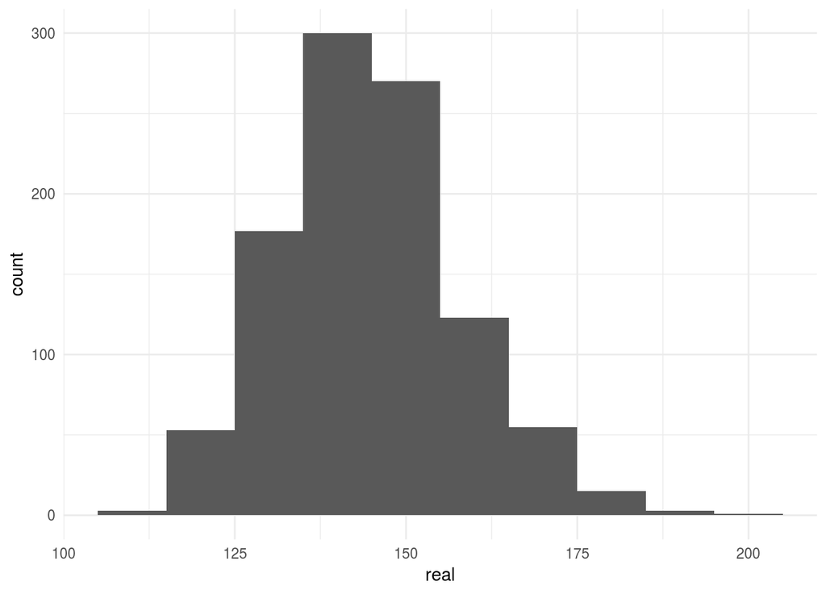

```r
n<-100
xn<-rnorm(n,5,1)
thetbbot<-function(){
  st<-sample(xn,n,replace=TRUE)
  exp(mean(st))
}
real<-rerun(1000,thetbbot())%>%flatten_dbl()
ggplot(data=NULL,aes(x=real))+geom_histogram(binwidth = 10)
```

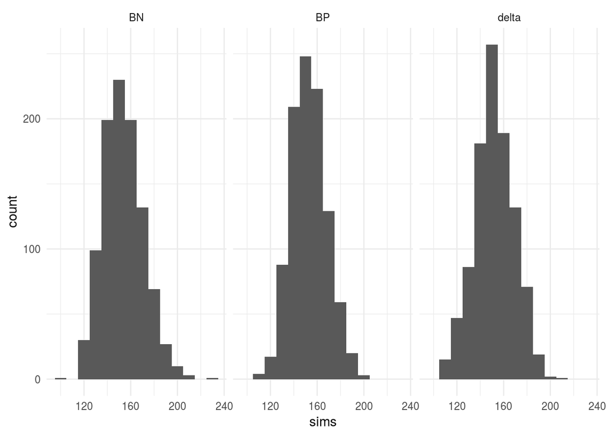

```r
ggplot(data=dat,aes(x=sims))+geom_histogram(binwidth = 10)+facet_wrap(~metodo)
```

Pista: $se(\hat{\mu}) = 1/\sqrt{n}$

2. La base de datos vancouver.csv contiene promedios de precipitación de mediciones (en mm) provenientes de Vancouver entre 1960 y 1994.

```r
van<-read.csv('vancouver.csv')
head(van)
```

```
#>    id  date prec
#> 1 182 jul01  1.6
#> 2 183 jul02  0.6
#> 3 184 jul03  3.1
#> 4 185 jul04  1.0
#> 5 186 jul05  3.9
#> 6 187 jul06  0.4
```

- Utiliza b-splines cúbicos para estudiar la relación entre el día y el promedio registrado. Deberás crear una variable numérica x que represente el día y utiliza como nudos los extremos y 3 puntos interiores igualmente espaciados, es decir, tendrás 4 regiones. Grafica la curva estimada.

```r
library(Hmisc)
```

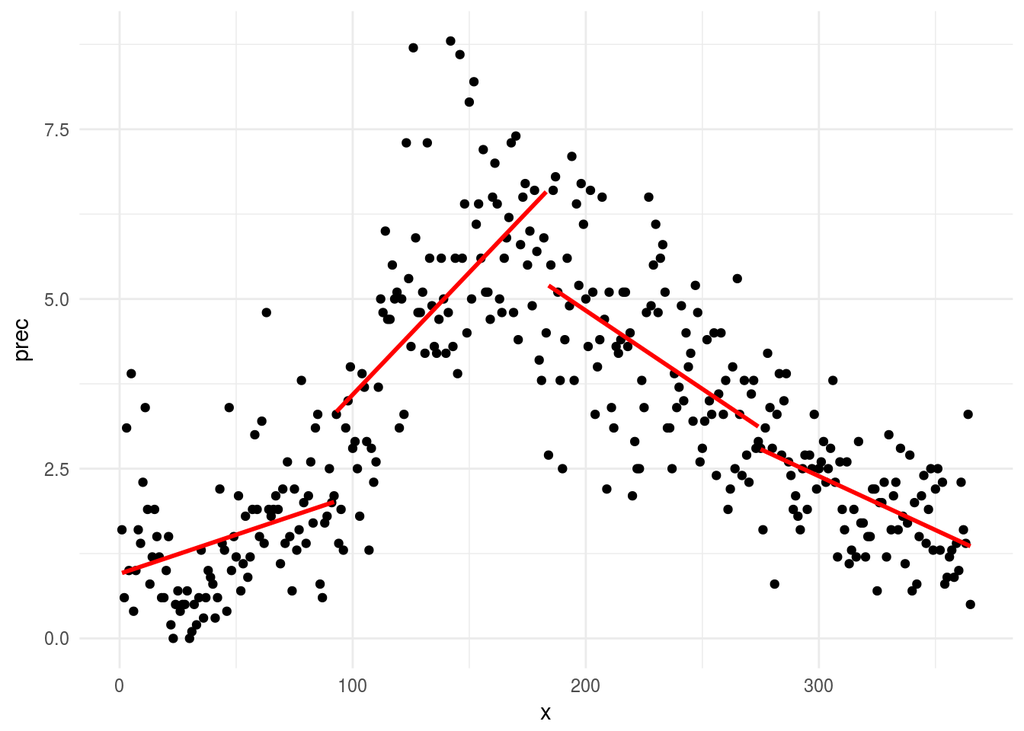

```r
n<-nrow(van)
c<-c(1:nrow(van))
van$x<-c


toy_k <- van %>%
    mutate(int = cut2(x, g = 4)) %>%
    group_by(int) %>%
    mutate(media = mean(prec))

ggplot(toy_k, aes(x, prec)) +
  geom_point() +
  geom_smooth(method = "lm", aes(x, y = prec, group = int), color = "red", se = FALSE)
```

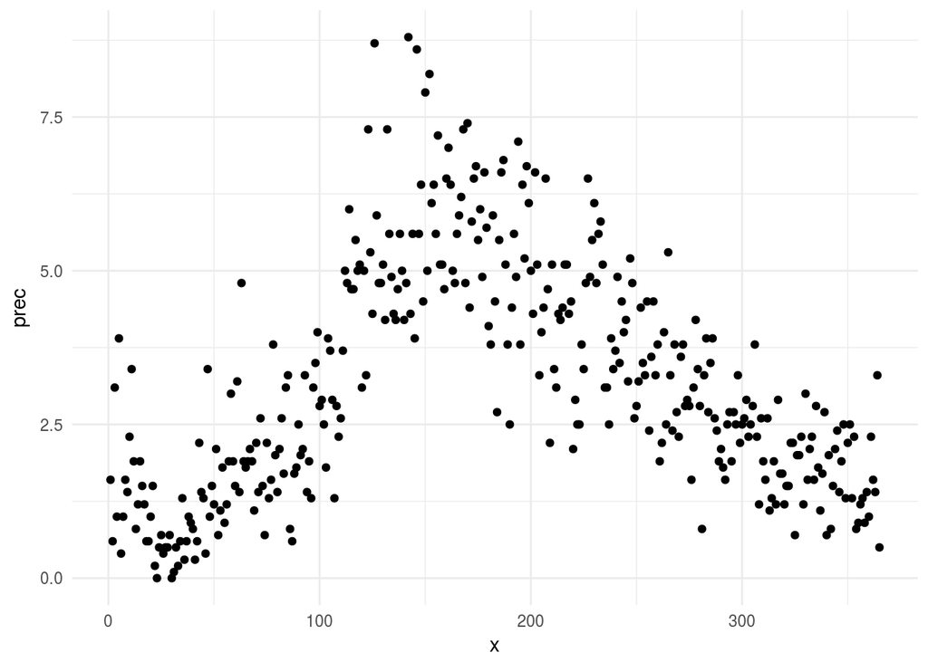

```r
ggplot(van,aes(x,prec))+geom_point()
```

```r
library(fda) # paquete con funciones útiles de splines
knots <- quantile(c)
knots
```

```
#>   0%  25%  50%  75% 100%
#>    1   92  183  274  365
```

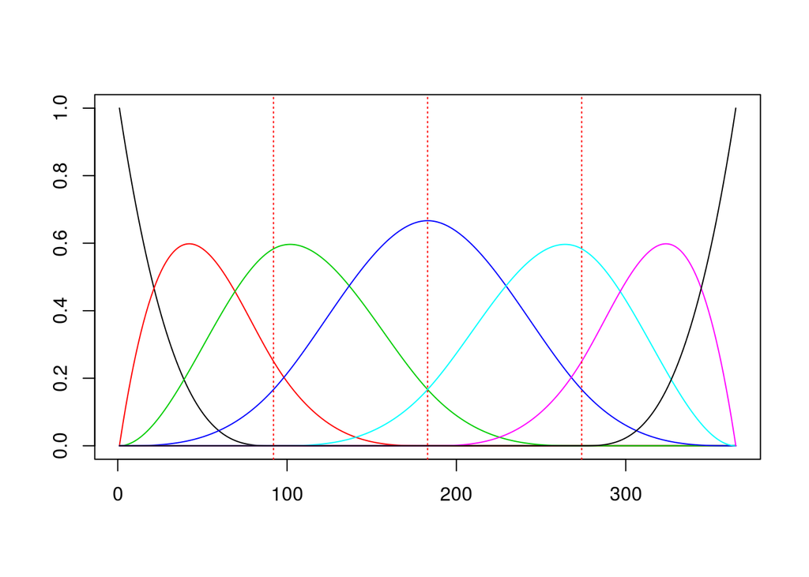

```r
  # usamos la función create.bspline.basis para crear la base
  base <- create.bspline.basis(
      norder = 4, # polinomios cúbicos
      breaks = knots # nodos en los cuartiles de x
      )
  plot(base, lty = "solid")
```

```r
H <- eval.basis(c, base)
head(H)
```

```
#>      bspl4.1 bspl4.2  bspl4.3  bspl4.4 bspl4.5 bspl4.6 bspl4.7
#> [1,]   1.000  0.0000 0.000000 0.00e+00       0       0       0
#> [2,]   0.967  0.0324 0.000180 2.21e-07       0       0       0
#> [3,]   0.936  0.0638 0.000715 1.77e-06       0       0       0
#> [4,]   0.904  0.0941 0.001597 5.97e-06       0       0       0
#> [5,]   0.874  0.1233 0.002820 1.42e-05       0       0       0
#> [6,]   0.844  0.1515 0.004376 2.76e-05       0       0       0
```

```r
beta_hat <- as.vector(solve(t(H) %*% H) %*% t(H) %*% toy_k$prec)
beta_hat
```

```
#> [1]  2.144 -0.682  3.590  6.964  1.898  2.121  1.356
```

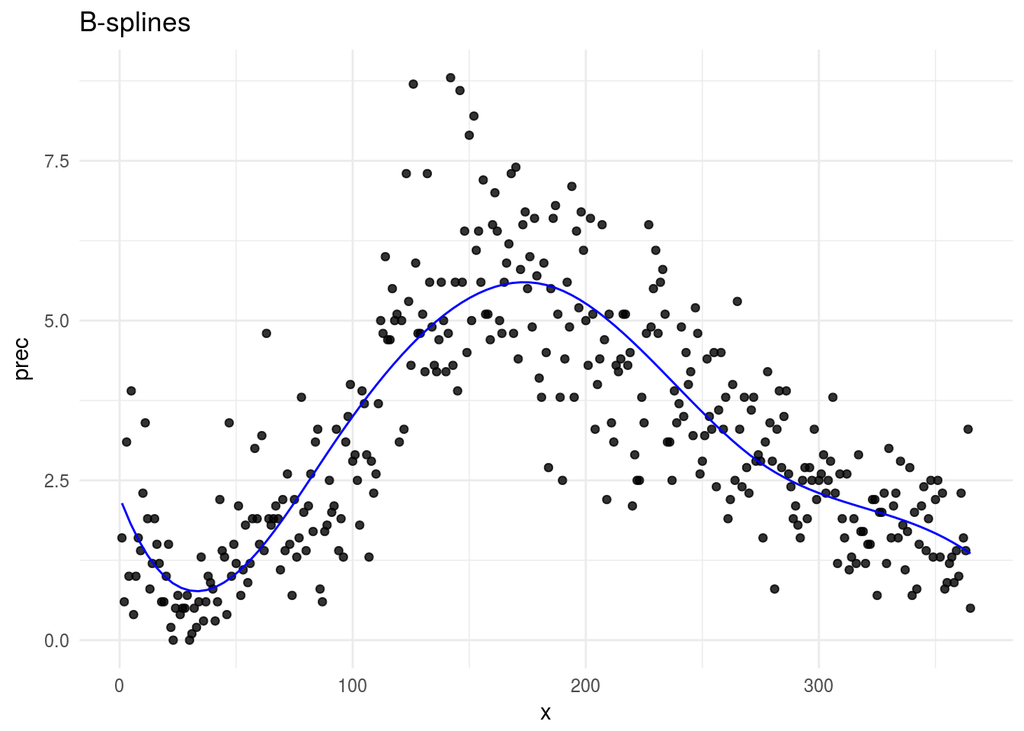

```r
# creamos una función que calcula mu(x)
mu <- function(c, betas){
    as.numeric(betas %*% t(eval.basis(c, base)))
}

ggplot(toy_k, aes(x = x, y = prec)) +
    geom_point(alpha = 0.8) +
    stat_function(fun = mu, args = list(betas = beta_hat), color = "blue") +
    labs(title = "B-splines")
```

- Crea bandas de errores estándar usando bootstrap paramético y suponiendo que los errores tienen una distribución normal.

Hacemos bootstrap parametrico dado que sabemos como se distribuyen los errores…

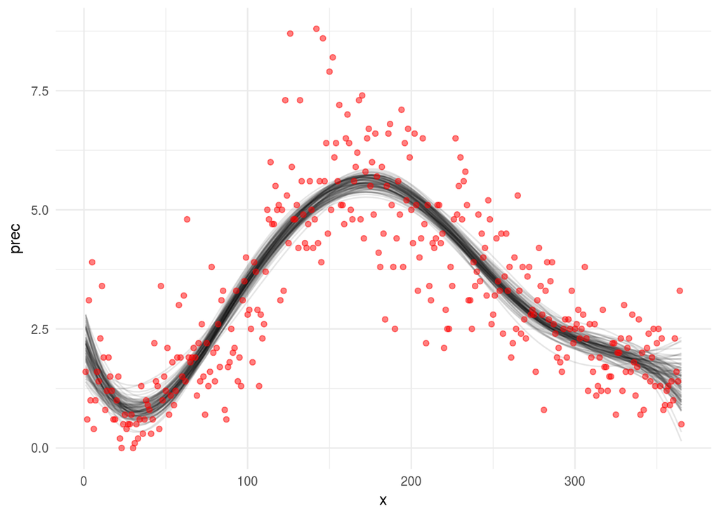

```r
mu_hat <- mu(toy_k$x, beta_hat)
sigma_hat <- sqrt(1 / n * sum((toy_k$prec - mu_hat) ^ 2))

# creamos las muestras bootstrap (paramétrico)
splinesBootP <- function(){
    toy_boot <- data.frame(x = toy_k$x, y = mu_hat + rnorm(n, 0, sigma_hat))
    H <- eval.basis(toy_boot$x, base)
    as.vector(solve(t(H) %*% H) %*% t(H) %*% toy_boot$y)
}

betas_p <- rerun(4000, splinesBootP()) %>% reduce(rbind)

splines_boot_p <- ggplot(toy_k, aes(x = x, y = prec))
for(i in 1:100){
    splines_boot_p <- splines_boot_p +
        stat_function(fun = mu, args = list(betas = betas_p[i, ]), alpha = 0.1)
}

splines_boot_p + geom_point(color = "red", alpha = 0.5)
```

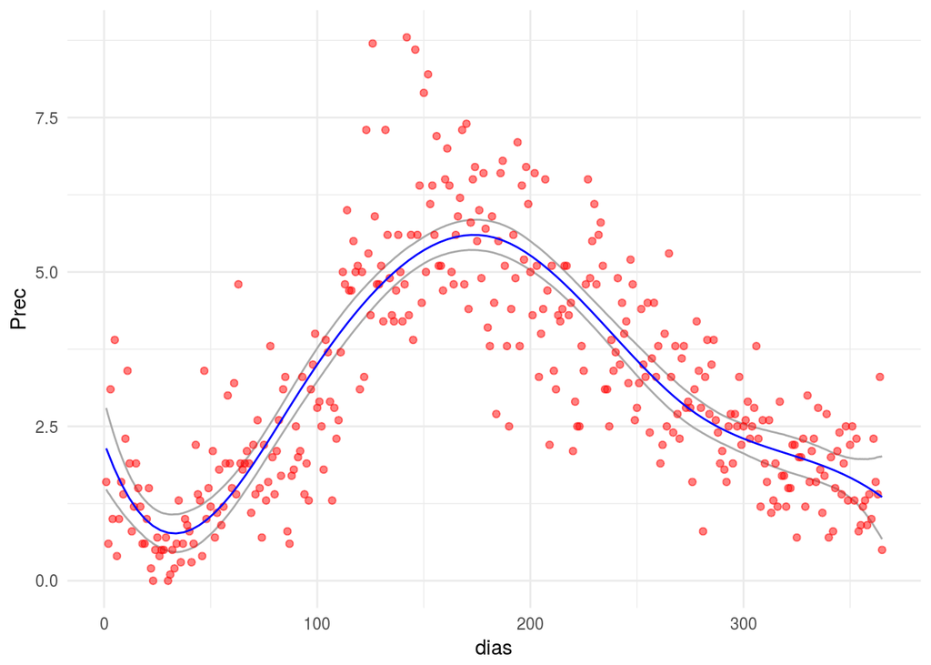

```r
# construimos los intervalos
x_grid <- seq(knots[1], knots[5], 0.03) # creamos un grid para evaluar mu(x)
H <- eval.basis(x_grid, base) # Evalúo la base en el rango
y <- betas_p %*% t(H) # calculo mu(x*)

betas_list <- split(betas_p, seq(nrow(betas_p)))
y <- purrr::map_df(betas_list, ~ data_frame(x = x_grid, mu = as.vector(. %*% t(H))))
limites <- y %>%
  group_by(x) %>%
  summarise(
    limite_inf = quantile(mu, probs = 0.025),
    limite_sup = quantile(mu, probs = 0.975)
    )

ggplot(limites) +
    geom_line(aes(x = x, y = limite_inf), color = "darkgray") +
    geom_line(aes(x = x, y = limite_sup), color = "darkgray") +
    geom_point(data = toy_k, aes(x = x, y = prec), color = "red", alpha = 0.5) +
    stat_function(fun = mu, args = list(betas = beta_hat), color = "blue") +
    labs(x = "dias", y = "Prec")
```